# Comparing Theoretical and Simulation Models

Pedro Cortes dos Santos

08/08/2021

## Simulations

```r
set.seed(1000)

lambda <- 0.2

n <- 40

sims <- 1000

running_sim <- replicate(sims, rexp(n,lambda))

means_expsim <- apply(running_sim,2, mean)
```

We’ll also generate a histogram of the simulated mean values.

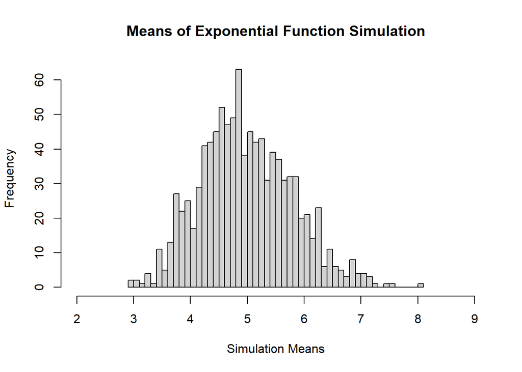

## Sample Mean x Theoretical Mean

The exponential distribution mean is 1/lambda. Considering that for this simulation lambda is 0.2, the theoretical mean should be 5.

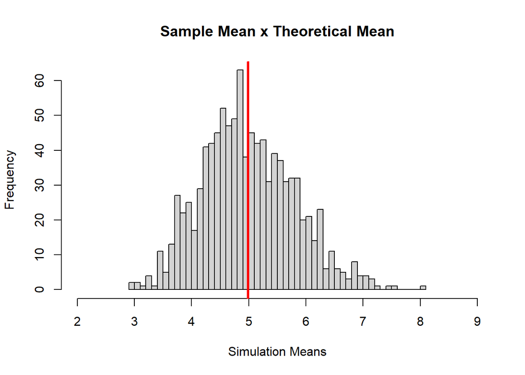

```r
mean(means_expsim)
```

```
## [1] 4.986963
```

The sample mean is approximately 4.98, very close to the theoretical mean of 5.

## Sample Variance x Theoretical Variance

The standard deviation of the exponential distribution is (1/lambda)/sqrt(n). So we’ll have to compare this equation to our previous simulations.

```r
print(paste("Theoretical Variance: ", round( (1/lambda)^2/n, 3)))
```

```
## [1] "Theoretical Variance:  0.625"
```

```r
print(paste("Sample Variance: ", round( var(means_expsim),3)))
```

```
## [1] "Sample Variance:  0.654"
```

Considering the previous results, we can say the sample variance is pretty close to the calculated variance.

## Distribution

The following investigates wheter the exponential distribution is approximately normal. Due to the Central Limit Theorem, the means of the sample simulations should follow a normal distribution.

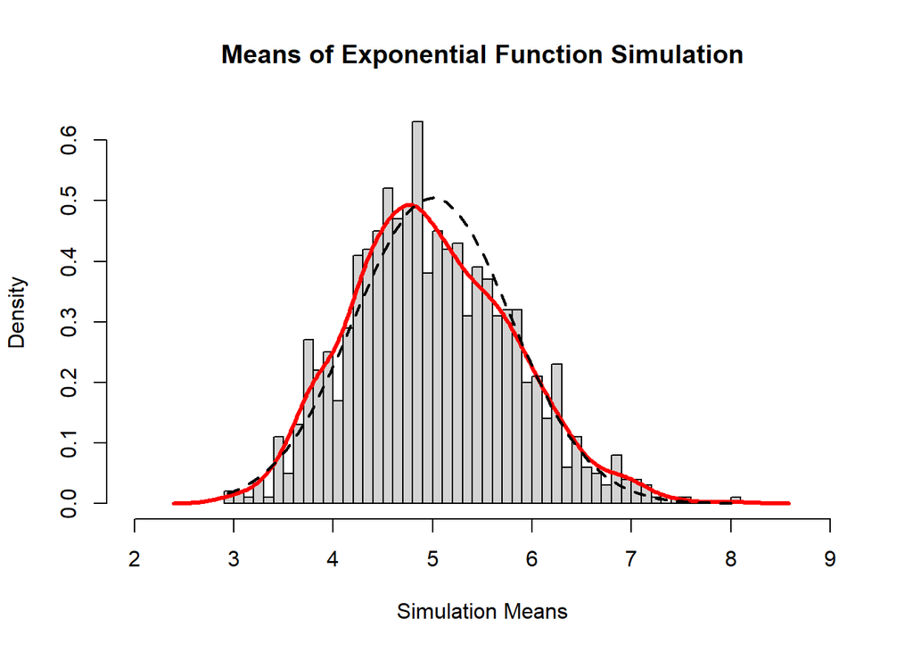